# rough_work

Hannes

2023-05-10

# 1 Data

plot deaths per day from 22.01.2020 to 29.04.2023 nationwide

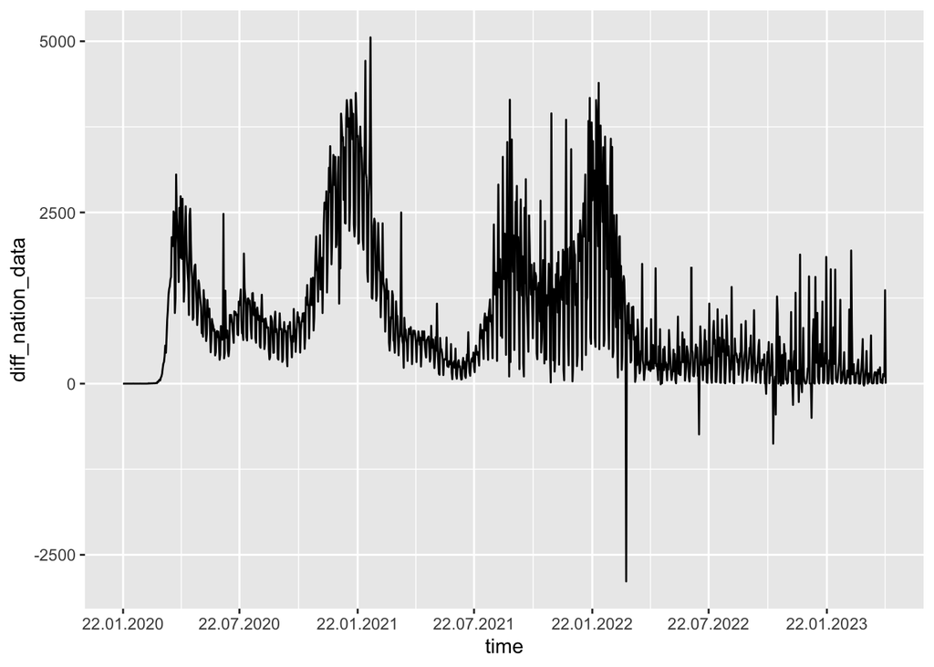

See that its very wiggly and some times even negative number of deaths per day, which is certainly not possible. This phenomenon occurs because, when counting the Covid deaths over time, certain death cases from a particular day may be subtracted due to counters believing they had overcounted on previous days. As a result, this can lead to a negative count of deaths on a given day.

To tackle this issue we apply smoothing to our data using kernel methods with a Gaussian kernel and bandwidth 7 (where the days are numerated from one to $n$ where $n$ is the total number of days in our data). We apply smoothing to each state separately.

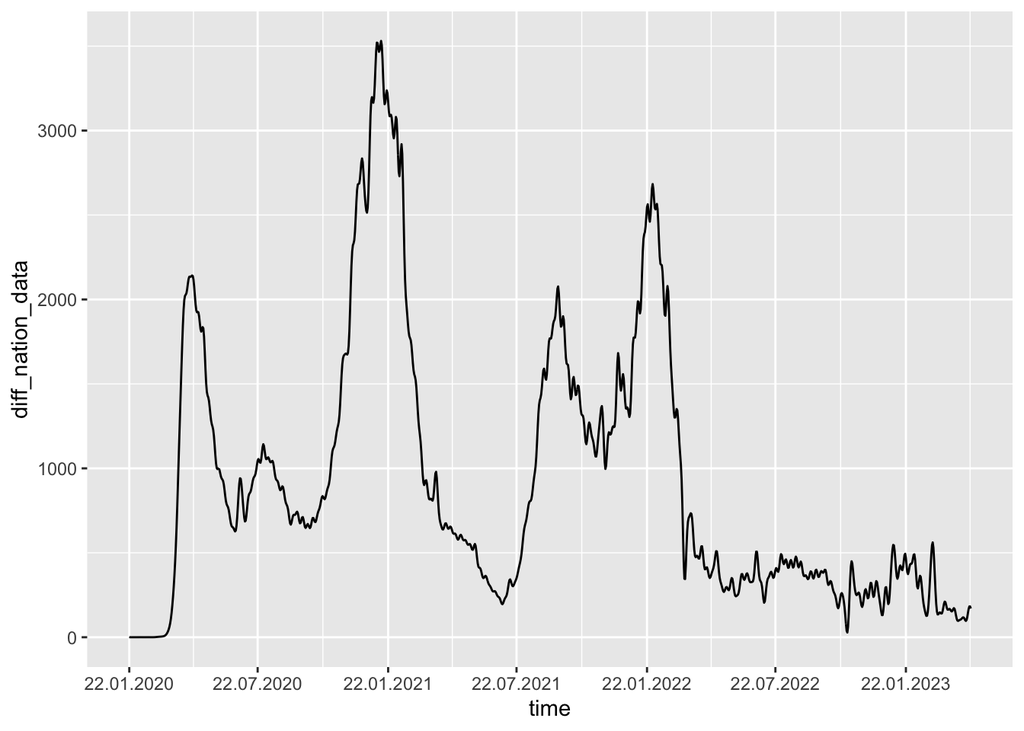

This already looks better and we got rid of negative values. So from now on we work with the smoothed values for the death numbers.